# Kebbi State — Malaria RDT Test Positivity Rate

MG2 facility-level analysis vs. DHIS2 indicator

May 30, 2026

## 1 Overview

This document computes malaria **RDT test positivity rate (TPR)** for **Kebbi State, Nigeria** using facility-level data from DHIS2, and compares the result against the DHIS2 pre-computed indicator.

**Data:** Nigeria DHIS2 national HMIS (`dhis2nigeria.org.ng`), 6-year download, facility and ward-level records, January 2020 – April 2026.

**TPR definition (RDT only):**

$$\text{TPR}_{\text{RDT}} = \frac{
\sum \text{Persons tested positive for malaria by RDT (all age
groups)}
}{
\sum \text{Persons presenting with fever \& tested by RDT (all age
groups)}
}$$

## 2 Load and filter data

```r
kebbi_path <- file.path(kebbi_dir, kebbi_file)

if (!file.exists(kebbi_path)) {
  message("Building Kebbi cache — loading full Nigeria file (~66M rows)...")
  d_all <- fst::read_fst(
    file.path(nigeria_dir, nigeria_file),
    as.data.table = TRUE
  )
  kebbi <- d_all[State == "ke Kebbi State"]
  rm(d_all)
  gc()

  # Month is stored as days-since-1970-01-01 in this FST; convert to yearmonth
  # so that build_combined_dataset() and as.Date(yearmonth(...)) work correctly
  kebbi[, Month := tsibble::yearmonth(as.Date(Month, origin = "1970-01-01"))]

  saveRDS(kebbi, kebbi_path)
  message("Cached: ", kebbi_path)
} else {
  kebbi <- readRDS(kebbi_path)
}

cat(
  "Kebbi facility-months (all elements):",
  format(nrow(kebbi), big.mark = ","),
  "\n"
)
```

```
#> Kebbi facility-months (all elements): 1,860,580
```

```r
cat(
  "Date range:",
  format(min(as.Date(kebbi$Month)), "%Y-%m"),
  "to",
  format(max(as.Date(kebbi$Month)), "%Y-%m"),
  "\n"
)
```

```
#> Date range: 2020-01 to 2026-04
```

```r
cat("Org unit levels:", paste(sort(unique(kebbi$level)), collapse = ", "), "\n")
```

```
#> Org unit levels: 4, 5
```

```r
cat(
  "Facilities (leaf):",
  format(sum(kebbi$effectiveLeaf & !duplicated(kebbi$orgUnit)), big.mark = ","),
  "\n"
)
```

```
#> Facilities (leaf): 996
```

## 3 Build TPR combined dataset

MG2’s `build_combined_dataset()` sums the four age-group categories of each data element to produce one numerator and one denominator value per facility-month, then applies the ratio validity rules:

- **Missing numerator + valid denominator** → numerator treated as 0 (zero positives is plausible; blank entry is common practice)
- **Present numerator + missing/zero denominator** → excluded
- **Numerator > denominator** → excluded (impossible ratio)

```r
steps <- list(list(
  operation = "Ratio",
  output_name = "TPR_RDT",
  max_value = 1,
  na_rm = TRUE,
  numerator = list(
    source_file = kebbi_file,
    cleaning_level = "original",
    data_values = c(
      "Persons tested positive for malaria by RDT_<5yrs",
      "Persons tested positive for malaria by RDT_>=5years",
      "Persons tested positive for malaria by RDT_\u22655yrs (excl PW)",
      "Persons tested positive for malaria by RDT_Preg Women (PW)"
    )
  ),
  denominator = list(
    source_file = kebbi_file,
    cleaning_level = "original",
    data_values = c(
      "Persons presenting with fever & tested by RDT_<5yrs",
      "Persons presenting with fever & tested by RDT_>=5years",
      "Persons presenting with fever & tested by RDT_\u22655yrs (excl PW)",
      "Persons presenting with fever & tested by RDT_Preg Women (PW)"
    )
  )
))

tpr_kebbi <- build_combined_dataset(
  steps = steps,
  data_folder = kebbi_dir,
  formula_name = "TPR_RDT",
  verbose = FALSE
)
```

```
#>
#> * build_combined_dataset: TPR_RDT
#> - data_folder: ~/Library/Mobile Documents/com~apple~CloudDocs/Projects/MG2/reports/Nigeria/
#> - steps: 1
#> - period type: Month
#>
#> - step 1 [ Ratio ] → TPR_RDT
#>   [Ratio] na.rm = TRUE
#>   [Ratio] numerator  → TPR_RDT ← file: kebbi_cache.rds | values: Persons tested positive for malaria by RDT_<5yrs, Persons tested positive for malaria by RDT_>=5years, Persons tested positive for malaria by RDT_≥5yrs (excl PW), Persons tested positive for malaria by RDT_Preg Women (PW) | cleaning…
#>    120696 rows after filter
#>   [Ratio] denominator → TPR_RDT ← file: kebbi_cache.rds | values: Persons presenting with fever & tested by RDT_<5yrs, Persons presenting with fever & tested by RDT_>=5years, Persons presenting with fever & tested by RDT_≥5yrs (excl PW), Persons presenting with fever & tested by RDT_Preg Women (P…
#>    122375 rows after filter
#>   num rows: 48423  | den rows: 48919
#>   joined rows: 49081
#>   non-NA ratio values: 48261
#>   missing_numerator: 658
#>   missing_denominator: 162
#>   step 1 produced 49081 rows
#>
#> - binding 1 result(s)
#> - over_max: ' TPR_RDT ' max = 1 → 522 flagged
#> - Phase 2: scanning combined values for outliers (smallThreshold=0)
#>    963 series to scan
#> - Phase 2 complete: mad15= 284  mad10= 599  seasonal5= 749  seasonal3= 1054
#> - done: 49081 rows | 1 variable(s): TPR_RDT
```

```r
setDT(tpr_kebbi)
cat("Kebbi TPR rows:", format(nrow(tpr_kebbi), big.mark = ","), "\n")
```

```
#> Kebbi TPR rows: 49,081
```

### 3.1 Reporting completeness by category

```r
fac <- tpr_kebbi[effectiveLeaf == TRUE]

fac[, .(
  total_rows = .N,
  valid_den_missing_num = sum(
    is.na(numerator) & !is.na(denominator) & denominator > 0
  ),
  both_valid = sum(
    !is.na(numerator) &
      !is.na(denominator) &
      denominator > 0 &
      numerator <= denominator
  ),
  orphaned_num = sum(
    !is.na(numerator) & (is.na(denominator) | denominator == 0)
  ),
  impossible_ratio = sum(
    !is.na(numerator) & !is.na(denominator) & numerator > denominator
  ),
  both_missing = sum(is.na(numerator) & is.na(denominator))
)] |>
  t() |>
  as.data.frame() |>
  setNames("n") |>
  within(pct <- round(n / n[1] * 100, 1))
```

|  | n | pct |
| --- | --- | --- |
| total_rows | 49081 | 100.0 |
| valid_den_missing_num | 188 | 0.4 |
| both_valid | 47739 | 97.3 |
| orphaned_num | 162 | 0.3 |
| impossible_ratio | 522 | 1.1 |
| both_missing | 0 | 0.0 |

## 4 TPR trend — Kebbi State

### 4.1 All facilities (aggregate)

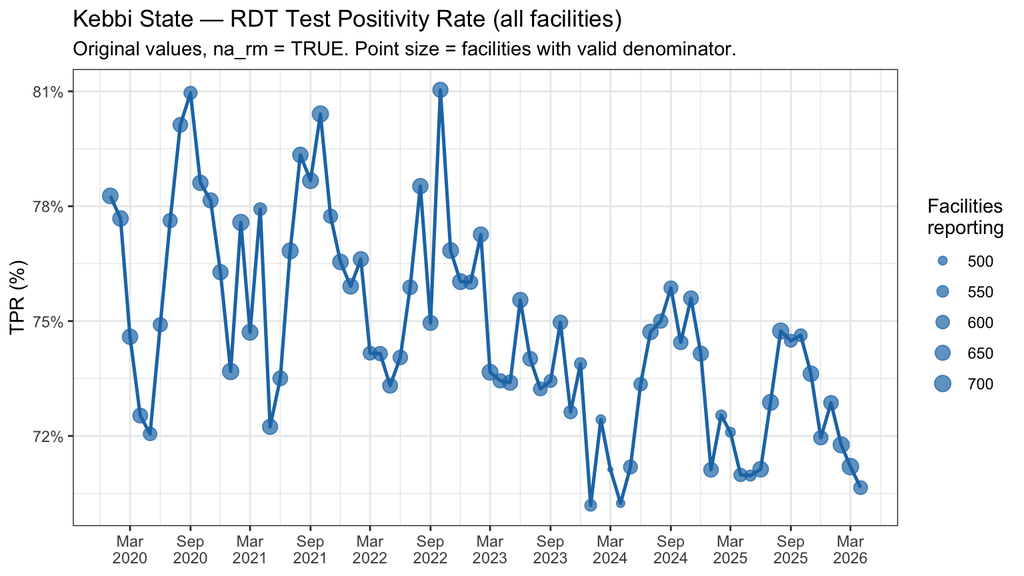

```r
# Apply validity rules and aggregate monthly
kebbi_monthly <- fac[
  !is.na(denominator) &
    denominator > 0 &
    (is.na(numerator) | numerator <= denominator),
  .(
    num = sum(fifelse(is.na(numerator), 0, numerator)),
    den = sum(denominator),
    n_fac = .N
  ),
  by = Month
]
kebbi_monthly[, `:=`(
  tpr_pct = num / den * 100,
  date = as.Date(yearmonth(as.character(Month)))
)]
setorder(kebbi_monthly, date)

ggplot(kebbi_monthly, aes(x = date)) +
  geom_line(aes(y = tpr_pct), colour = "#1f78b4", linewidth = 0.9) +
  geom_point(aes(y = tpr_pct, size = n_fac), colour = "#1f78b4", alpha = 0.7) +
  scale_size_continuous(name = "Facilities\nreporting", range = c(1, 4)) +
  scale_y_continuous(labels = function(x) paste0(x, "%")) +
  scale_x_date(date_breaks = "6 months", date_labels = "%b\n%Y") +
  labs(
    title = "Kebbi State — RDT Test Positivity Rate (all facilities)",
    subtitle = "Original values, na_rm = TRUE. Point size = facilities with valid denominator.",
    x = NULL,
    y = "TPR (%)"
  ) +
  theme_bw()
```

```r
kebbi_monthly[, .(
  date,
  positives = num,
  tested = den,
  tpr_pct = round(tpr_pct, 1),
  n_fac
)]
```

| date | positives | tested | tpr_pct | n_fac |
| --- | --- | --- | --- | --- |
| 2020-01-01 | 52131 | 66604 | 78.3 | 672 |
| 2020-02-01 | 57964 | 74619 | 77.7 | 669 |
| 2020-03-01 | 49605 | 66503 | 74.6 | 663 |
| 2020-04-01 | 43374 | 59800 | 72.5 | 642 |
| 2020-05-01 | 32487 | 45088 | 72.1 | 598 |
| 2020-06-01 | 39695 | 52993 | 74.9 | 619 |
| 2020-07-01 | 42384 | 54601 | 77.6 | 619 |
| 2020-08-01 | 55810 | 69653 | 80.1 | 635 |
| 2020-09-01 | 57909 | 71528 | 81.0 | 589 |
| 2020-10-01 | 69747 | 88725 | 78.6 | 662 |

[output cut: 66 more lines]

### 4.2 Facility-level TPR distribution

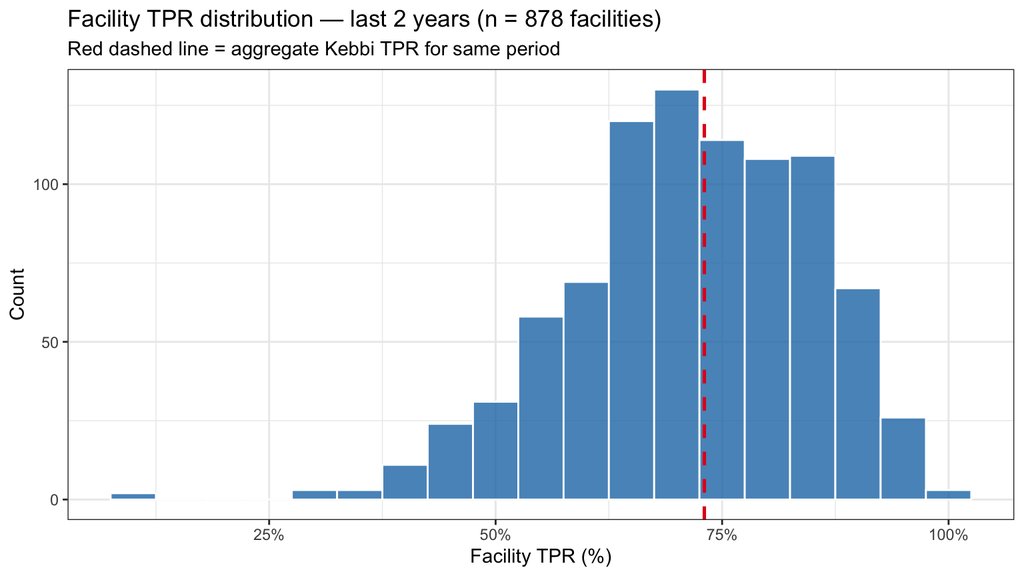

```r
# Compute per-facility average TPR for recent 2 years
recent_cutoff <- as.Date(max(kebbi_monthly$date)) - 365 * 2

fac_avg <- fac[
  as.Date(yearmonth(as.character(Month))) >= recent_cutoff &
    !is.na(denominator) &
    denominator > 0 &
    (is.na(numerator) | numerator <= denominator),
  .(
    num_total = sum(fifelse(is.na(numerator), 0, numerator)),
    den_total = sum(denominator),
    n_months = .N
  ),
  by = orgUnit
]
fac_avg[, tpr_pct := num_total / den_total * 100]
fac_avg <- fac_avg[den_total > 0]

# Join facility names from kebbi (orgUnitName not preserved by build_combined_dataset)
ou_names <- unique(kebbi[effectiveLeaf == TRUE, .(orgUnit, orgUnitName)])
fac_avg <- ou_names[fac_avg, on = "orgUnit"]

ggplot(fac_avg, aes(x = tpr_pct)) +
  geom_histogram(
    binwidth = 5,
    fill = "#1f78b4",
    colour = "white",
    alpha = 0.8
  ) +
  geom_vline(
    xintercept = kebbi_monthly[
      date >= recent_cutoff,
      sum(num) / sum(den) * 100
    ],
    linetype = "dashed",
    colour = "#e31a1c",
    linewidth = 0.9
  ) +
  scale_x_continuous(labels = function(x) paste0(x, "%")) +
  labs(
    title = paste0(
      "Facility TPR distribution — last 2 years (n = ",
      nrow(fac_avg),
      " facilities)"
    ),
    subtitle = "Red dashed line = aggregate Kebbi TPR for same period",
    x = "Facility TPR (%)",
    y = "Count"
  ) +
  theme_bw()
```

## 5 Champion facility analysis

Champion facilities are those that report consistently — here defined as having a valid denominator (tested count > 0) in at least a specified fraction of months during the analysis window.

```r
# Analysis window: full date range in the data
date_range <- range(kebbi_monthly$date)
n_months_total <- nrow(kebbi_monthly)

# Count months each facility reported a valid denominator
fac_report_counts <- fac[
  !is.na(denominator) & denominator > 0,
  .(n_reported = .N),
  by = orgUnit
]
fac_all <- fac[, .(n_total = .N), by = orgUnit]
fac_summary <- merge(fac_all, fac_report_counts, by = "orgUnit", all.x = TRUE)
fac_summary[is.na(n_reported), n_reported := 0]
fac_summary[, pct_reported := n_reported / n_months_total * 100]

cat(
  "Facilities with ≥80% reporting:",
  sum(fac_summary$pct_reported >= 80),
  "\n"
)
```

```
#> Facilities with ≥80% reporting: 489
```

```r
cat(
  "Facilities with ≥60% reporting:",
  sum(fac_summary$pct_reported >= 60),
  "\n"
)
```

```
#> Facilities with ≥60% reporting: 599
```

```r
cat(
  "Facilities with ≥40% reporting:",
  sum(fac_summary$pct_reported >= 40),
  "\n"
)
```

```
#> Facilities with ≥40% reporting: 724
```

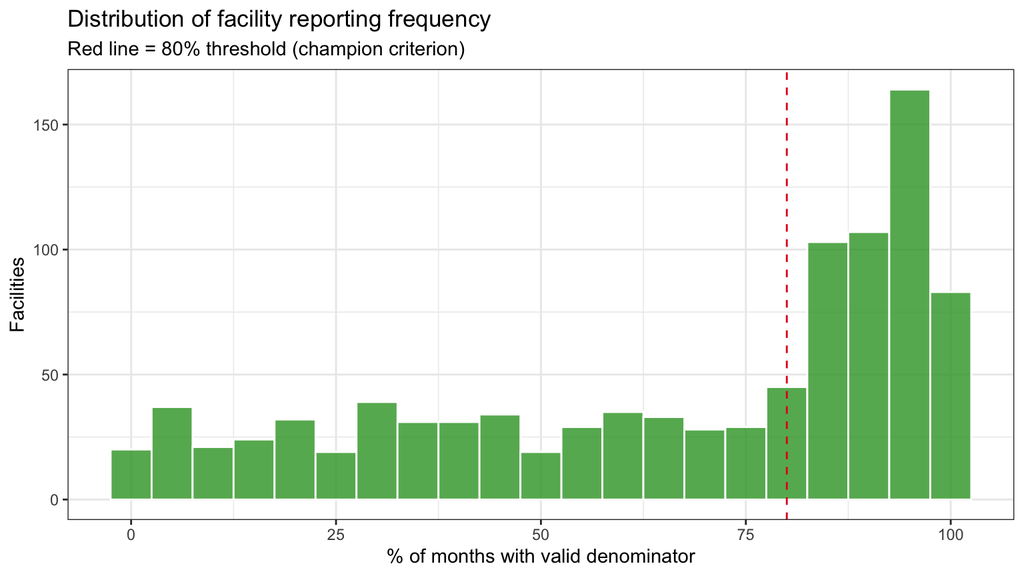

```r
ggplot(fac_summary, aes(x = pct_reported)) +
  geom_histogram(
    binwidth = 5,
    fill = "#33a02c",
    colour = "white",
    alpha = 0.8
  ) +
  geom_vline(xintercept = 80, linetype = "dashed", colour = "#e31a1c") +
  labs(
    title = "Distribution of facility reporting frequency",
    subtitle = "Red line = 80% threshold (champion criterion)",
    x = "% of months with valid denominator",
    y = "Facilities"
  ) +
  theme_bw()
```

```r
champion_ids <- fac_summary[pct_reported >= 80, orgUnit]
cat("Champion facilities (≥80%):", length(champion_ids), "\n")
```

```
#> Champion facilities (≥80%): 489
```

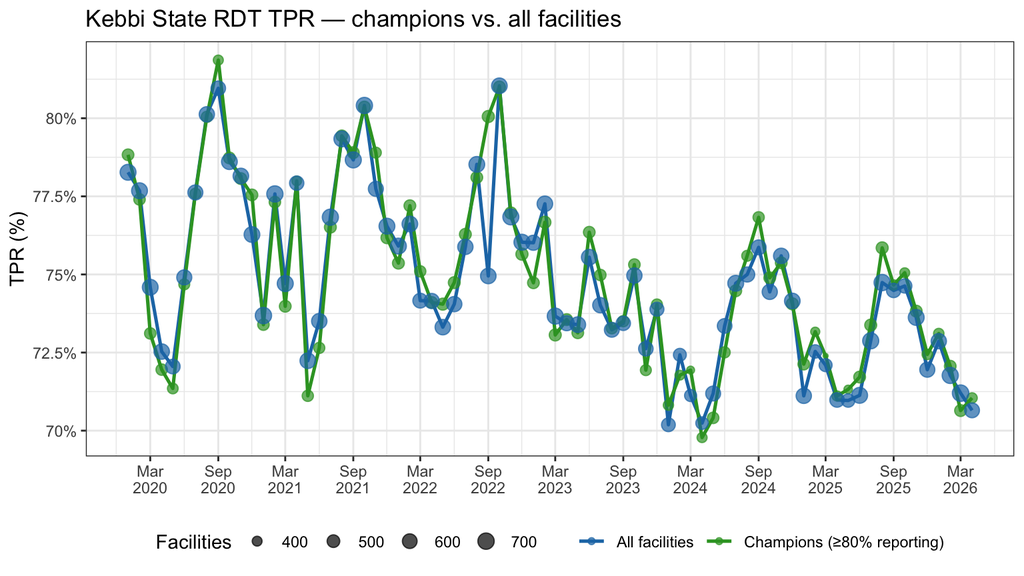

```r
# Monthly TPR: champions vs. all
champ_monthly <- fac[
  orgUnit %in%
    champion_ids &
    !is.na(denominator) &
    denominator > 0 &
    (is.na(numerator) | numerator <= denominator),
  .(
    num = sum(fifelse(is.na(numerator), 0, numerator)),
    den = sum(denominator),
    n_fac = .N
  ),
  by = Month
]
champ_monthly[, `:=`(
  tpr_pct = num / den * 100,
  date = as.Date(yearmonth(as.character(Month))),
  group = "Champions (≥80% reporting)"
)]

all_monthly <- copy(kebbi_monthly)[, group := "All facilities"]
setnames(all_monthly, "tpr_pct", "tpr_pct")

plot_champ <- rbind(
  champ_monthly[, .(date, tpr_pct, n_fac, group)],
  all_monthly[, .(date, tpr_pct, n_fac, group)]
)

ggplot(plot_champ, aes(x = date, y = tpr_pct, colour = group)) +
  geom_line(linewidth = 0.9) +
  geom_point(aes(size = n_fac), alpha = 0.7) +
  scale_colour_manual(
    values = c(
      "Champions (≥80% reporting)" = "#33a02c",
      "All facilities" = "#1f78b4"
    )
  ) +
  scale_size_continuous(name = "Facilities", range = c(1, 4)) +
  scale_y_continuous(labels = function(x) paste0(x, "%")) +
  scale_x_date(date_breaks = "6 months", date_labels = "%b\n%Y") +
  labs(
    title = "Kebbi State RDT TPR — champions vs. all facilities",
    x = NULL,
    y = "TPR (%)",
    colour = NULL
  ) +
  theme_bw() +
  theme(legend.position = "bottom")
```

## 6 Comparison with DHIS2 indicators

Nigeria’s DHIS2 instance contains two indicators that nominally measure RDT test positivity. They have **different formulas** and produce divergent results — a ~50 percentage point gap in Kebbi State post-2021.

[output not shown]

For a full decomposition of both indicator formulas, the NHMIS form transition evidence, programme context, and reproducible approach, see **nigeria_tpr_indicator_error.html**.

```r
library(httr)

DHIS2_CACHE <- file.path(kebbi_dir, "kebbi_dhis2_indicators.rds")

kebbi_ou <- "M689V9w3Gs3"

# One period string per year — sent as separate requests to avoid timeouts.
# Each element is a ";"-joined list of YYYYMM codes for that calendar year.
period_batches <- c(
  paste0(2020, sprintf("%02d", 1:12), collapse = ";"),
  paste0(2021, sprintf("%02d", 1:12), collapse = ";"),
  paste0(2022, sprintf("%02d", 1:12), collapse = ";"),
  paste0(2023, sprintf("%02d", 1:12), collapse = ";"),
  paste0(2024, sprintf("%02d", 1:12), collapse = ";"),
  paste0(2025, sprintf("%02d", 1:12), collapse = ";"),
  paste0(2026, sprintf("%02d", 1:4),  collapse = ";")
)

# fetch_indicator(): loops over annual period batches, one request per year,
# then combines results.  Returns NULL only if every batch fails.
fetch_indicator <- function(ind_id, label, base_url, username, password,
                            batch_pause = 1) {
  cat("Fetching:", label, "\n")
  cat("Indicator UID:", ind_id, "| batches:", length(period_batches), "\n\n")

  batch_results <- vector("list", length(period_batches))

  for (i in seq_along(period_batches)) {
    yr_label <- substr(period_batches[[i]], 1, 4)   # "2020", "2021", …
    url <- paste0(
      base_url,
      "api/analytics.json",
      "?dimension=dx:", ind_id,
      "&dimension=pe:", period_batches[[i]],
      "&dimension=ou:", kebbi_ou,
      "&includeNumDen=true&skipRounding=false&displayProperty=NAME"
    )

    cat("  Batch", i, "(", yr_label, "):", url, "\n")

    resp <- tryCatch(
      GET(url, authenticate(username, password), timeout(30)),
      error = function(e) {
        cat("    ERROR (connection):", conditionMessage(e), "\n")
        NULL
      }
    )

    if (is.null(resp)) {
      cat("    RESULT: no response (timeout or DNS failure) — skipping\n")
      next
    }

    sc <- status_code(resp)
    cat("    HTTP:", sc)

    if (sc == 401) {
      cat(" — authentication failed, aborting all batches\n")
      return(NULL)
    }
    if (sc != 200) {
      cat(" — unexpected status, skipping batch\n")
      cat("    Body:", rawToChar(content(resp, "raw")), "\n")
      next
    }

    d <- content(resp, as = "parsed")
    if (length(d$rows) == 0) {
      cat(" — 0 rows returned\n")
      next
    }

    rows <- lapply(d$rows, function(r) {
      data.frame(
        period      = r[[2]],
        value       = as.numeric(r[[4]]),
        numerator   = as.numeric(r[[5]]),
        denominator = as.numeric(r[[6]]),
        stringsAsFactors = FALSE
      )
    })
    batch_results[[i]] <- as.data.table(do.call(rbind, rows))
    cat(" —", nrow(batch_results[[i]]), "rows\n")

    if (i < length(period_batches)) Sys.sleep(batch_pause)
  }

  combined <- rbindlist(Filter(Negate(is.null), batch_results))
  if (nrow(combined) == 0) {
    cat("\n  RESULT: no data returned across all batches\n")
    return(NULL)
  }

  combined[, `:=`(
    date  = as.Date(paste0(period, "01"), format = "%Y%m%d"),
    label = label
  )]
  cat("\n  TOTAL:", nrow(combined), "rows,",
      format(min(combined$date), "%Y-%m"), "–",
      format(max(combined$date), "%Y-%m"), "\n")
  combined
}
```

```r
# ── Load from cache or fetch from DHIS2 ────────────────────────────────────
# Re-run this chunk interactively to force a fresh download:
#   delete kebbi_dhis2_indicators.rds, or set force_fetch <- TRUE

force_fetch <- FALSE   # ← set TRUE to bypass cache

if (!force_fetch && file.exists(DHIS2_CACHE)) {

  cat("Loading DHIS2 indicators from cache:", DHIS2_CACHE, "\n")
  dhis2_cache <- readRDS(DHIS2_CACHE)
  dhis2_correct <- dhis2_cache$correct
  dhis2_errored <- dhis2_cache$errored
  cat("  correct indicator rows:", if (is.null(dhis2_correct)) "NULL" else nrow(dhis2_correct), "\n")
  cat("  errored indicator rows:", if (is.null(dhis2_errored)) "NULL" else nrow(dhis2_errored), "\n")

} else {

  cat("Fetching DHIS2 indicators from live instance...\n")
  cat("Base URL:", creds$url, "\n\n")

  dhis2_correct <- fetch_indicator(
    "l2eIpdluuTI",
    "DHIS2 Indicator A (l2eIpdluuTI)",
    creds$url, creds$username, creds$password
  )

  cat("\n")

  dhis2_errored <- fetch_indicator(
    "uiA07P72s2Z",
    "DHIS2 Indicator B (uiA07P72s2Z)",
    creds$url, creds$username, creds$password
  )

  if (!is.null(dhis2_correct) || !is.null(dhis2_errored)) {
    saveRDS(
      list(correct = dhis2_correct, errored = dhis2_errored),
      DHIS2_CACHE
    )
    cat("\nSaved to cache:", DHIS2_CACHE, "\n")
  } else {
    cat("\nBoth fetches failed — nothing saved to cache.\n")
  }
}
```

```
#> Loading DHIS2 indicators from cache: ~/Library/Mobile Documents/com~apple~CloudDocs/Projects/MG2/reports/Nigeria//kebbi_dhis2_indicators.rds
#>   correct indicator rows: 76
#>   errored indicator rows: 16
```

```r
if (is.null(dhis2_correct)) {
  cat("\n⚠  dhis2_correct is NULL — Section 6 comparison plots will be skipped.\n")
}
```

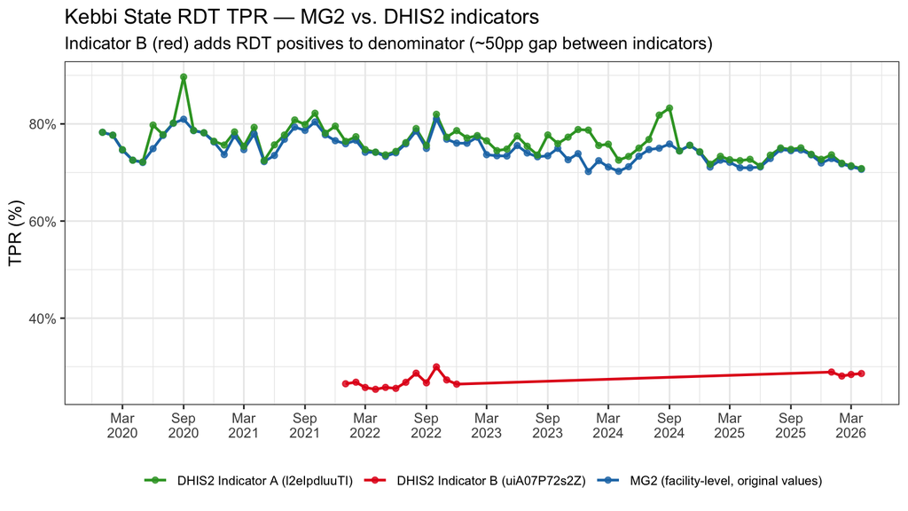

```r
mg2_line <- kebbi_monthly[, .(
  date,
  value = tpr_pct,
  numerator = num,
  denominator = den,
  label = "MG2 (facility-level, original values)"
)]

all_series <- rbindlist(
  Filter(
    Negate(is.null),
    list(
      mg2_line,
      dhis2_correct[, .(date, value, numerator, denominator,
                        label = "DHIS2 Indicator A (l2eIpdluuTI)")],
      dhis2_errored[, .(date, value, numerator, denominator,
                        label = "DHIS2 Indicator B (uiA07P72s2Z)")]
    )
  ),
  fill = TRUE
)

ggplot(all_series, aes(x = date, y = value, colour = label)) +
  geom_line(linewidth = 0.8) +
  geom_point(size = 1.5, alpha = 0.8) +
  scale_colour_manual(
    values = c(
      "MG2 (facility-level, original values)" = "#1f78b4",
      "DHIS2 Indicator A (l2eIpdluuTI)"       = "#33a02c",
      "DHIS2 Indicator B (uiA07P72s2Z)"       = "#e31a1c"
    )
  ) +
  scale_y_continuous(labels = function(x) paste0(x, "%")) +
  scale_x_date(date_breaks = "6 months", date_labels = "%b\n%Y") +
  labs(
    title = "Kebbi State RDT TPR — MG2 vs. DHIS2 indicators",
    subtitle = "Indicator B (red) adds RDT positives to denominator (~50pp gap between indicators)",
    x = NULL,
    y = "TPR (%)",
    colour = NULL
  ) +
  theme_bw() +
  theme(legend.position = "bottom", legend.text = element_text(size = 8))
```

### 6.1 Why MG2 counts differ from Indicator A

The raw facility-level sums (before validity filtering) match DHIS2 Indicator A (`l2eIpdluuTI`) exactly every month. All differences come from MG2’s **facility-level validity rules**, which DHIS2’s pre-computed indicator does not apply.

```r
fac[, num_adj := fifelse(
  is.na(numerator) & !is.na(denominator) & denominator > 0, 0, numerator
)]
fac[, valid := !is.na(num_adj) & !is.na(denominator) &
               denominator > 0 & num_adj <= denominator]

total_fm    <- nrow(fac)
missing_den <- fac[is.na(denominator) | denominator == 0, .N]
num_gt_den  <- fac[!is.na(numerator) & !is.na(denominator) &
                     denominator > 0 & numerator > denominator, .N]
missing_num <- fac[is.na(numerator) & !is.na(denominator) & denominator > 0, .N]

cat("=== Facility-month validity breakdown ===\n")
```

```
#> === Facility-month validity breakdown ===
```

```r
cat(sprintf("Total facility-months:                %6d\n", total_fm))
```

```
#> Total facility-months:                 49081
```

```r
cat(sprintf("Missing/zero denominator (excluded):  %6d  (%4.1f%%)\n",
            missing_den,  missing_den  / total_fm * 100))
```

```
#> Missing/zero denominator (excluded):     632  ( 1.3%)
```

```r
cat(sprintf("Numerator > denominator (excluded):   %6d  (%4.1f%%)\n",
            num_gt_den,   num_gt_den   / total_fm * 100))
```

```
#> Numerator > denominator (excluded):      522  ( 1.1%)
```

```r
cat(sprintf("Missing numerator, valid den (→ 0):   %6d  (%4.1f%%)\n",
            missing_num,  missing_num  / total_fm * 100))
```

```
#> Missing numerator, valid den (→ 0):      188  ( 0.4%)
```

```r
monthly_raw  <- fac[, .(raw_num  = sum(numerator, na.rm = TRUE),
                        raw_den  = sum(denominator, na.rm = TRUE)), by = Month]
monthly_filt <- fac[valid == TRUE, .(filt_num = sum(num_adj),
                                     filt_den = sum(denominator)), by = Month]

monthly_raw[,  date := as.Date(yearmonth(as.character(Month)))]
monthly_filt[, date := as.Date(yearmonth(as.character(Month)))]

diff_tbl <- merge(monthly_raw[, .(date, raw_num, raw_den)],
                  monthly_filt[, .(date, filt_num, filt_den)],
                  by = "date")
diff_tbl <- merge(diff_tbl,
                  as.data.table(dhis2_correct)[, .(date, d2_num = numerator, d2_den = denominator)],
                  by = "date")
diff_tbl[, `:=`(num_diff = raw_num - filt_num, den_diff = raw_den - filt_den)]

cat("=== Raw sums match DHIS2 Indicator A exactly? ===\n")
```

```
#> === Raw sums match DHIS2 Indicator A exactly? ===
```

```r
cat("Months where raw_num != d2_num:", diff_tbl[raw_num != d2_num, .N], "\n")
```

```
#> Months where raw_num != d2_num: 0
```

```r
cat("Months where raw_den != d2_den:", diff_tbl[raw_den != d2_den, .N], "\n\n")
```

```
#> Months where raw_den != d2_den: 0
```

```r
cat("=== Months where MG2 filtered != raw (differs from DHIS2) ===\n")
```

```
#> === Months where MG2 filtered != raw (differs from DHIS2) ===
```

```r
diff_tbl[num_diff != 0 | den_diff != 0,
         .(date,
           `DHIS2 A (=raw) num` = format(d2_num,   big.mark = ","),
           `MG2 filt num`       = format(filt_num,  big.mark = ","),
           `num removed`        = format(num_diff,  big.mark = ","),
           `DHIS2 A (=raw) den` = format(d2_den,   big.mark = ","),
           `MG2 filt den`       = format(filt_den,  big.mark = ","),
           `den removed`        = format(den_diff,  big.mark = ","))]
```

| date | DHIS2 A (=raw) num | MG2 filt num | num removed | DHIS2 A (=raw) den | MG2 filt den | den removed |
| --- | --- | --- | --- | --- | --- | --- |
| 2020-03-01 | 49,704 | 49,605 | 99 | 66,536 | 66,503 | 33 |
| 2020-05-01 | 32,665 | 32,487 | 178 | 45,253 | 45,088 | 165 |
| 2020-06-01 | 42,356 | 39,695 | 2,661 | 53,101 | 52,993 | 108 |
| 2020-07-01 | 42,504 | 42,384 | 120 | 54,636 | 54,601 | 35 |
| 2020-08-01 | 55,870 | 55,810 | 60 | 69,681 | 69,653 | 28 |
| 2020-09-01 | 64,251 | 57,909 | 6,342 | 71,642 | 71,528 | 114 |
| 2020-10-01 | 69,799 | 69,747 | 52 | 88,725 | 88,725 | 0 |
| 2020-11-01 | 55,563 | 55,542 | 21 | 71,069 | 71,069 | 0 |
| 2020-12-01 | 53,475 | 53,338 | 137 | 69,959 | 69,926 | 33 |
| 2021-01-01 | 50,696 | 49,100 | 1,596 | 67,014 | 66,636 | 378 |

[output cut: 61 more lines]

The raw facility sums equal DHIS2 Indicator A to the digit. Every difference comes from three validity rules applied at facility level:

1. **Numerator > denominator — primary driver.** Facility-months where recorded positives exceed tested count are dropped. Because the numerator was inflated *above* the denominator, removing them reduces the numerator more than the denominator.
2. **Missing/zero denominator.** Facility-months with no tested count are excluded entirely. DHIS2 sums the numerator for those rows regardless.
3. **Missing numerator → 0 (minor, offsetting).** When a facility has a valid tested count but no positives recorded, MG2 imputes zero. The effect (0.4% of facility-months) is smaller than the exclusions above.

The magnitude of removed counts has grown in recent years (2024–2025: up to ~9,000 positives removed in a single month), suggesting a deteriorating data quality signal worth monitoring independently of the TPR calculation itself.

### 6.2 Numerator / denominator comparison

```r
# Compare counts for DHIS2 Indicator A vs. MG2
nd_compare <- merge(
  mg2_line[, .(date, mg2_num = numerator, mg2_den = denominator)],
  dhis2_correct[, .(date, dhis2_num = numerator, dhis2_den = denominator)],
  by = "date",
  all = TRUE
)
nd_compare[, `:=`(
  num_ratio = round(mg2_num / dhis2_num, 2),
  den_ratio = round(mg2_den / dhis2_den, 2)
)]
nd_compare
```

| date | mg2_num | mg2_den | dhis2_num | dhis2_den | num_ratio | den_ratio |
| --- | --- | --- | --- | --- | --- | --- |
| 2020-01-01 | 52131 | 66604 | 52131 | 66604 | 1.00 | 1.00 |
| 2020-02-01 | 57964 | 74619 | 57964 | 74619 | 1.00 | 1.00 |
| 2020-03-01 | 49605 | 66503 | 49704 | 66536 | 1.00 | 1.00 |
| 2020-04-01 | 43374 | 59800 | 43374 | 59800 | 1.00 | 1.00 |
| 2020-05-01 | 32487 | 45088 | 32665 | 45253 | 0.99 | 1.00 |
| 2020-06-01 | 39695 | 52993 | 42356 | 53101 | 0.94 | 1.00 |
| 2020-07-01 | 42384 | 54601 | 42504 | 54636 | 1.00 | 1.00 |
| 2020-08-01 | 55810 | 69653 | 55870 | 69681 | 1.00 | 1.00 |
| 2020-09-01 | 57909 | 71528 | 64251 | 71642 | 0.90 | 1.00 |
| 2020-10-01 | 69747 | 88725 | 69799 | 88725 | 1.00 | 1.00 |

[output cut: 66 more lines]

Raw facility sums match DHIS2 Indicator A exactly. Differences here reflect MG2’s validity filtering — see §6.1 for a full breakdown.

## 7 Notes on outlier cleaning

This analysis uses **original values** throughout. The same analysis with `cleaning_level = "mad10"` would exclude values flagged as more than 10× the median absolute deviation from the series median. To explore this, change the `cleaning_level` argument in Section 3 to `"mad10"` and re-render.

```r
# Preview: how many facility-months are flagged at each cleaning level in Kebbi
rdt_pos <- kebbi[data %like% "Persons tested positive.*RDT"]
rdt_tested <- kebbi[data %like% "Persons presenting.*RDT"]

cat("=== Numerator (RDT positives) ===\n")
```

```
#> === Numerator (RDT positives) ===
```

```r
rdt_pos[, .(
  total = .N,
  over_max = sum(over_max, na.rm = TRUE),
  mad15 = sum(mad15, na.rm = TRUE),
  mad10 = sum(mad10, na.rm = TRUE),
  seasonal5 = sum(seasonal5, na.rm = TRUE),
  seasonal3 = sum(seasonal3, na.rm = TRUE)
)]
```

| total | over_max | mad15 | mad10 | seasonal5 | seasonal3 |
| --- | --- | --- | --- | --- | --- |
| 120696 | 0 | 184 | 412 | 256 | 448 |

```r
cat("\n=== Denominator (RDT tested) ===\n")
```

```
#>
#> === Denominator (RDT tested) ===
```

```r
rdt_tested[, .(
  total = .N,
  over_max = sum(over_max, na.rm = TRUE),
  mad15 = sum(mad15, na.rm = TRUE),
  mad10 = sum(mad10, na.rm = TRUE),
  seasonal5 = sum(seasonal5, na.rm = TRUE),
  seasonal3 = sum(seasonal3, na.rm = TRUE)
)]
```

| total | over_max | mad15 | mad10 | seasonal5 | seasonal3 |
| --- | --- | --- | --- | --- | --- |
| 122375 | 0 | 199 | 416 | 300 | 495 |

*Analysis run: 2026-05-30 10:01:06.746873 | Data: malaria_All-levels_6yrs_2026-05-26.fst | MG2 version: 0.1.5*